# reesehs_OriginalHomeworkCode_03

```r
library(curl)
f <- curl("https://raw.githubusercontent.com/fuzzyatelin/fuzzyatelin.github.io/master/AN588_Fall23/zombies.csv") #imports data about zombies
d <- read.csv(f, header = TRUE, sep = ",", stringsAsFactors = FALSE)  #reads data and creates data frame from it
head(d) #returns data frame
```

```
##   id first_name last_name gender   height   weight zombies_killed
## 1  1      Sarah    Little Female 62.88951 132.0872              2
## 2  2       Mark    Duncan   Male 67.80277 146.3753              5
## 3  3    Brandon     Perez   Male 72.12908 152.9370              1
## 4  4      Roger   Coleman   Male 66.78484 129.7418              5
## 5  5      Tammy    Powell Female 64.71832 132.4265              4
## 6  6    Anthony     Green   Male 71.24326 152.5246              1
##   years_of_education                           major      age
## 1                  1                medicine/nursing 17.64275
## 2                  3 criminal justice administration 22.58951
## 3                  1                       education 21.91276
## 4                  6                  energy studies 18.19058
## 5                  3                       logistics 21.10399
## 6                  4                  energy studies 21.48355
```

## Question One: Calculate the population mean and standard deviation for each quantitative random variable (height, weight, age, number of zombies killed, and years of education). NOTE: You will not want to use the built in var() and sd() commands as these are for samples.

```r
#height
height <- (d$height) #takes data from the column height in the data from d
mh <- mean(height) #takes the mean of the height data
sqrt(sum((height - mean(height))^2)/length(height)) #calculates the standard deviation of height data
```

```
## [1] 4.30797
```

```r
#weight
weight <- (d$weight)
mw <- mean(weight)
sqrt(sum((weight - mean(weight))^2)/length(weight))
```

```
## [1] 18.39186
```

```r
#age
age <- (d$age)
ma <- mean(age)
sqrt(sum((age - mean(age))^2)/length(age))
```

```
## [1] 2.963583
```

```r
#number of zombies killed
zk <- (d$zombies_killed)
mzk <- mean(zk)
sqrt(sum((zk - mean(zk))^2)/length(zk))
```

```
## [1] 1.747551
```

```r
#years of education
yoedu <- (d$years_of_education)
myoedu <- mean(yoedu)
sqrt(sum((yoedu - mean(yoedu))^2)/length(yoedu))
```

```
## [1] 1.675704
```

```r
#vbhavya Peer comment: I like the way you named your variables. It's quite easy to keep track of. I use x,y and z repeatedly so it variables keep being rewritten and I sometimes can't use them again. Your way seems so intuitive but I didn't think of it.
```

## Question 2: Use {ggplot} to make boxplots of each of these variables by gender

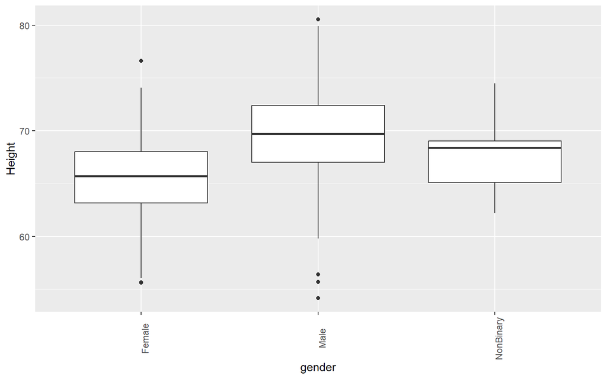

```r
library(ggplot2)
p <- ggplot(data = d, aes(x = gender, y = height)) #create graph with data from gender in x axis and data from height in y axis, all data is taken from the data frame d
p <- p + geom_boxplot()  #create boxplot
p <- p + theme(axis.text.x = element_text(angle = 90)) #shift angle of x axis
p <- p + ylab("Height") #labels y axis
p
```

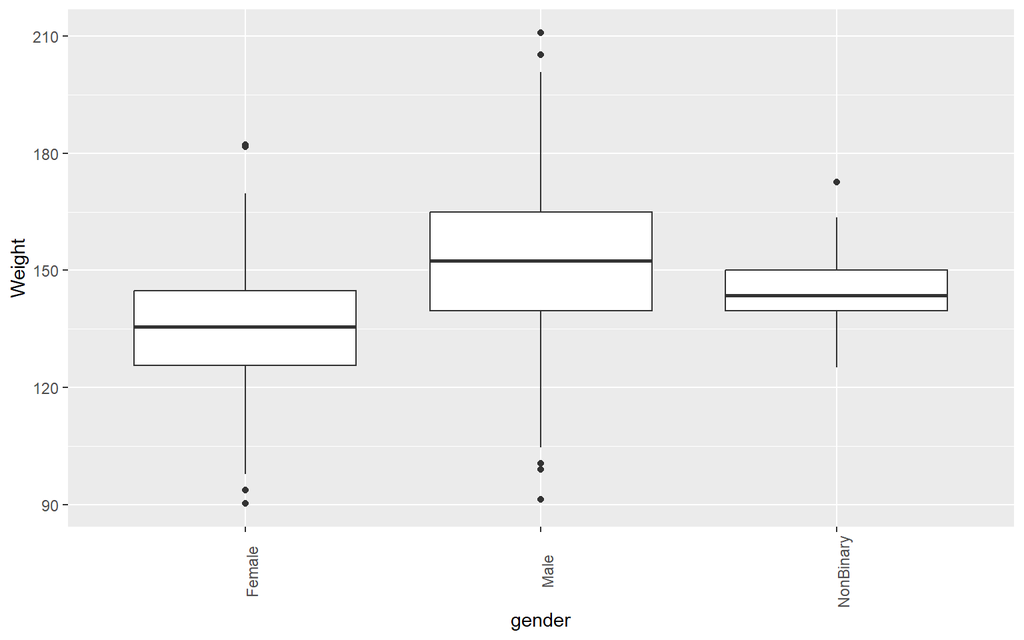

```r
w <- ggplot(data = d, aes(x = gender, y = weight))
w <- w + geom_boxplot()
w <- w + theme(axis.text.x = element_text(angle = 90))
w <- w + ylab("Weight")
w
```

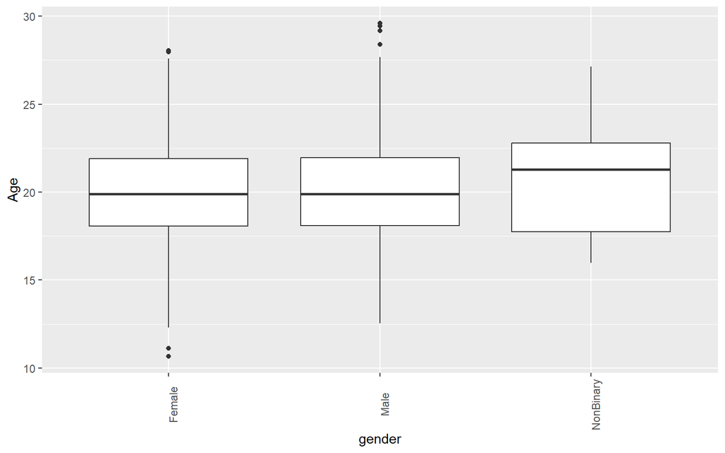

```r
a <- ggplot(data = d, aes(x = gender, y = age))
a <- a + geom_boxplot()
a <- a + theme(axis.text.x = element_text(angle = 90))
a <- a + ylab("Age")
a
```

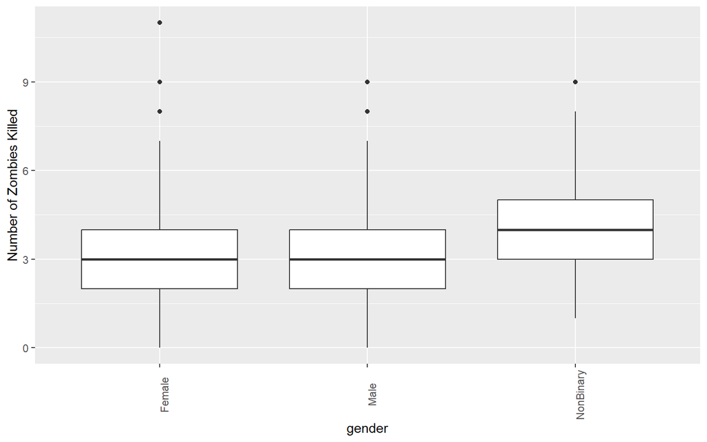

```r
zn <- ggplot(data = d, aes(x = gender, y = zk))
zn <- zn + geom_boxplot()
zn <- zn + theme(axis.text.x = element_text(angle = 90))
zn <- zn + ylab("Number of Zombies Killed")
zn
```

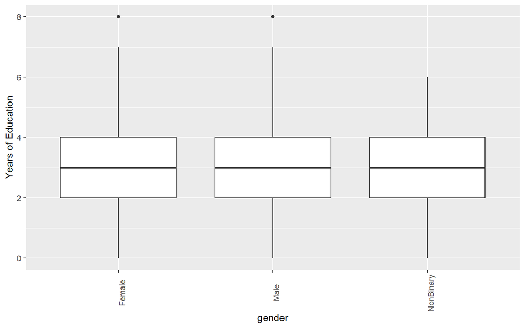

```r
ey <- ggplot(data = d, aes(x = gender, y = yoedu))
ey <- ey + geom_boxplot()
ey <- ey + theme(axis.text.x = element_text(angle = 90))
ey <- ey + ylab("Years of Education")
ey
```

```r
#vbhavya Peer comments:
# 1. I like how you did name each plot. Again, I'm often in such a rush that I forget to do that. It's a great practice.
# 2. I don't actually think you need to do the multiple steps in ggplot to add details into a graph. I know that's how Chris did it in the modules and it's probably a good practice. But I wrote this code: p <- ggplot(data = d, aes(x = gender, y = age,
#color = factor(gender))) + geom_boxplot()
#p
#It still works. Just letting you know so you can choose the way you prefer. A part of learning how to code is figuring out which way you like to code.
# 3. You might want to experiment with different themes or add colors to the graph. This isn't necessary but it helps with visualisation to have different colors (especially when you evetually make figures for reports or papers)
```

## Question 3: Use {ggplot} to make scatterplots of height and weight in relation to age. Do these variables seem to be related? In what way?

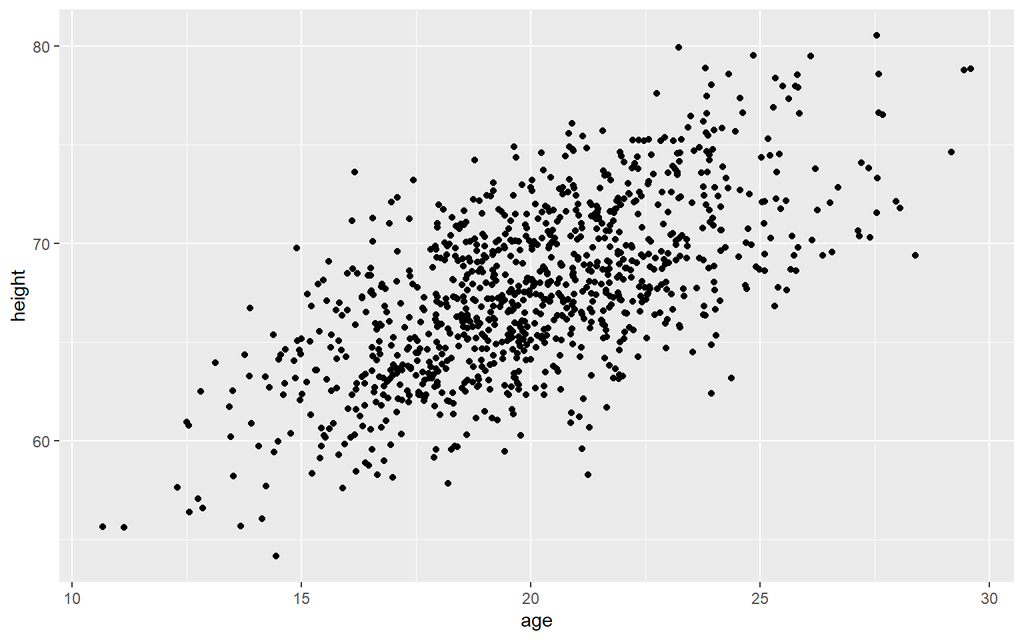

```r
hg <- ggplot(data = d, aes(x = age, y = height)) + geom_point() + xlab("age") + ylab("height") + theme(legend.position = "bottom", legend.title = element_blank()) #creates scatter plot ggplot using data from age and height(in data frame d) with x and y axises labeled
hg
```

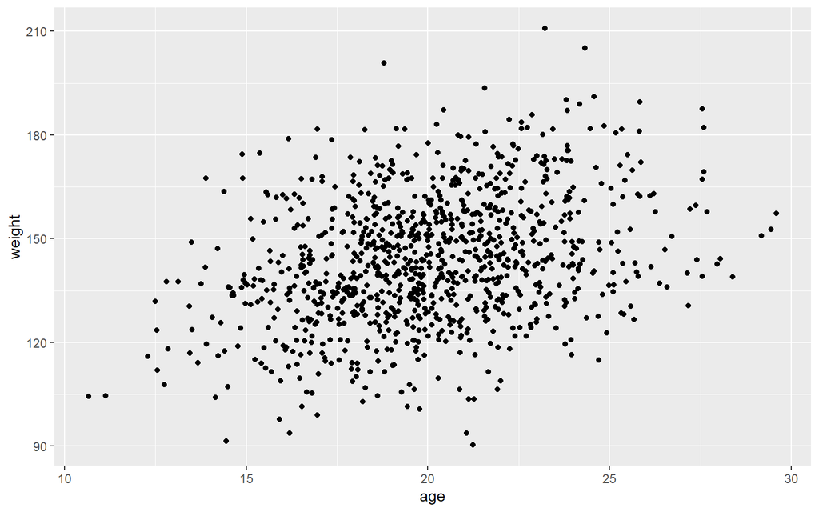

```r
wg <- ggplot(data = d, aes(x = age, y = weight)) + geom_point() + xlab("age") + ylab("weight") + theme(legend.position = "bottom", legend.title = element_blank())
wg
```

```r
# As age increases so do both weight and height. The scatter plots demonstrate an upward slope that shows this relationship.

#vbhavya Peer comment: Just something to think about: are there differences between how height and weight vary with age? Now that we've also been introduced to linear regression, it might be useful to think about this relationship in terms of where the best fit regression would be. Again, you've done what was asked of you really well. But I think it's fun to think of how age affects the two variables differently. In fact, the age-height plot doesn't even look linear but that might just be me overthinking.
```

## Question 4: Using histograms and Q-Q plots, check whether the quantitative variables seem to be drawn from a normal distribution. Which seem to be and which do not (hint: not all are drawn from the normal distribution)? For those that are not normal, can you determine from which common distribution they are drawn?

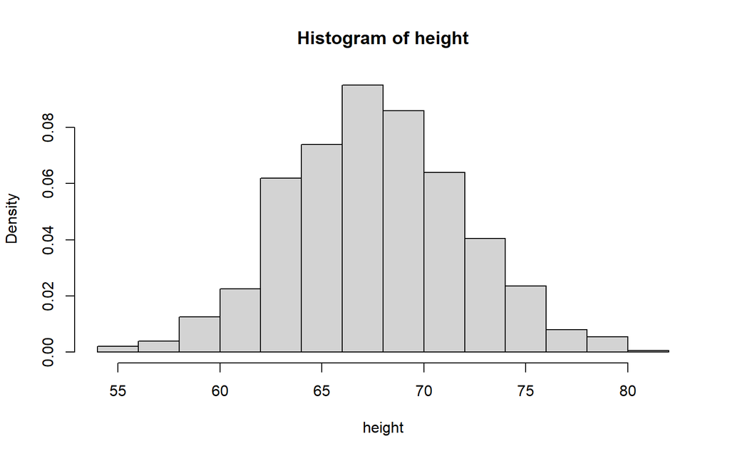

```r
hist(height, probability = TRUE) #creates histogram using height data and comparing the probability
```

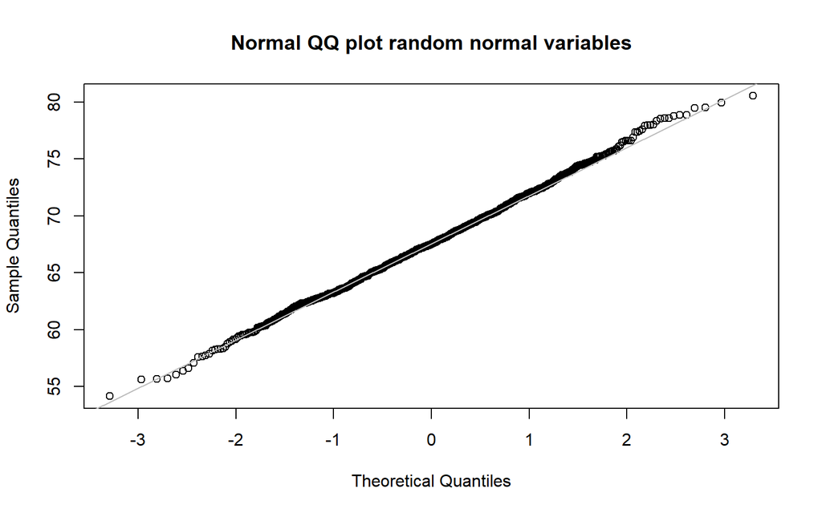

```r
qqnorm(height, main = "Normal QQ plot random normal variables")  #creates qqnorm graph to test normal distribution
qqline(height, col = "gray") #create line that is the normal distribution
```

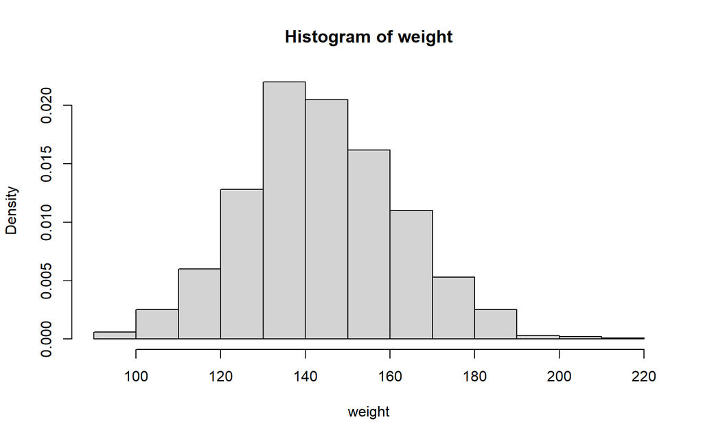

```r
hist(weight, probability = TRUE)
```

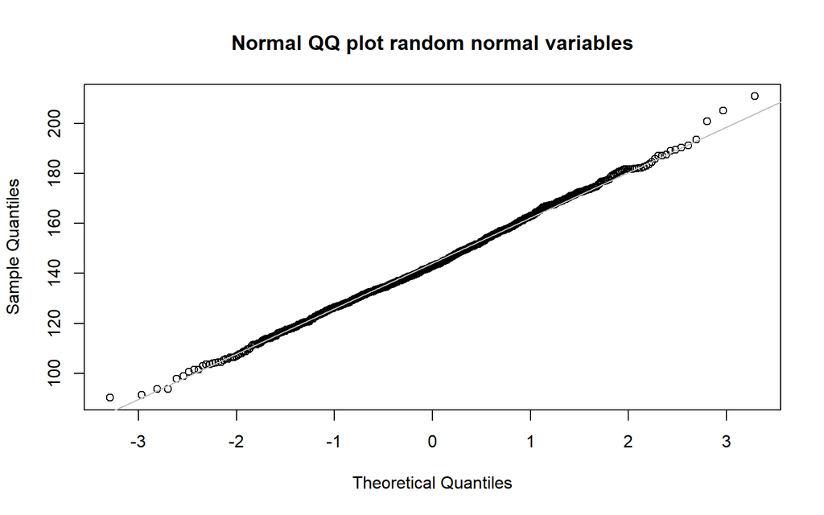

```r
qqnorm(weight, main = "Normal QQ plot random normal variables")
qqline(weight, col = "gray")
```

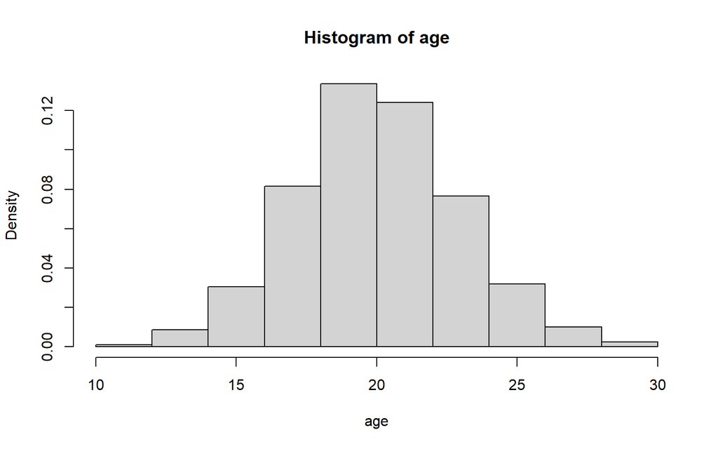

```r
hist(age, probability = TRUE)
```

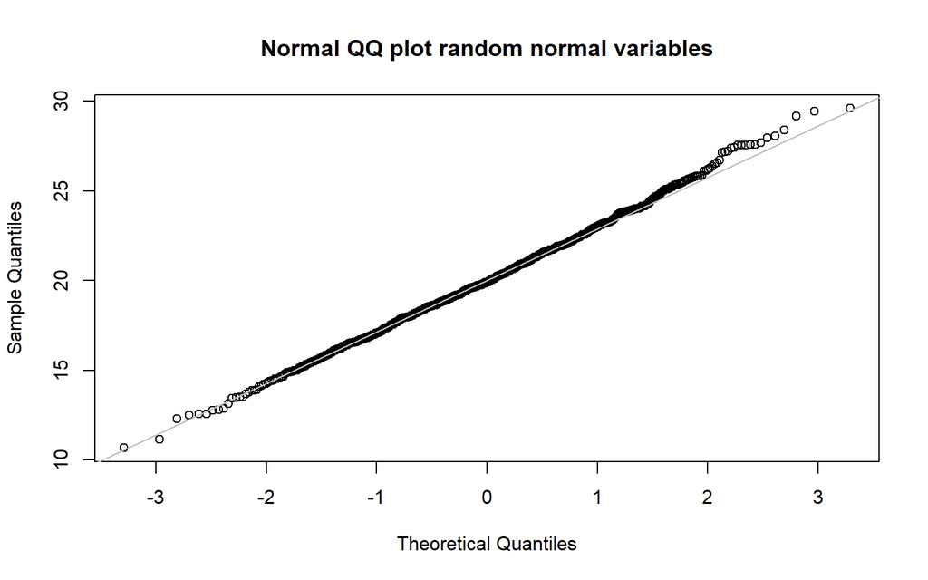

```r
qqnorm(age, main = "Normal QQ plot random normal variables")
qqline(age, col = "gray")
```

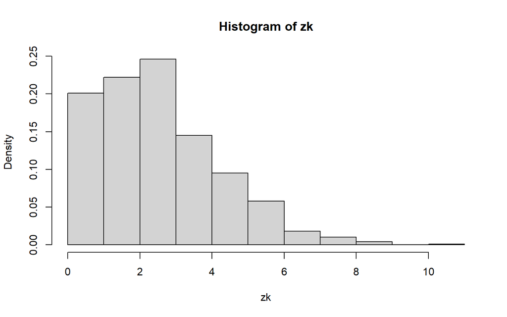

```r
hist(zk, probability = TRUE)
```

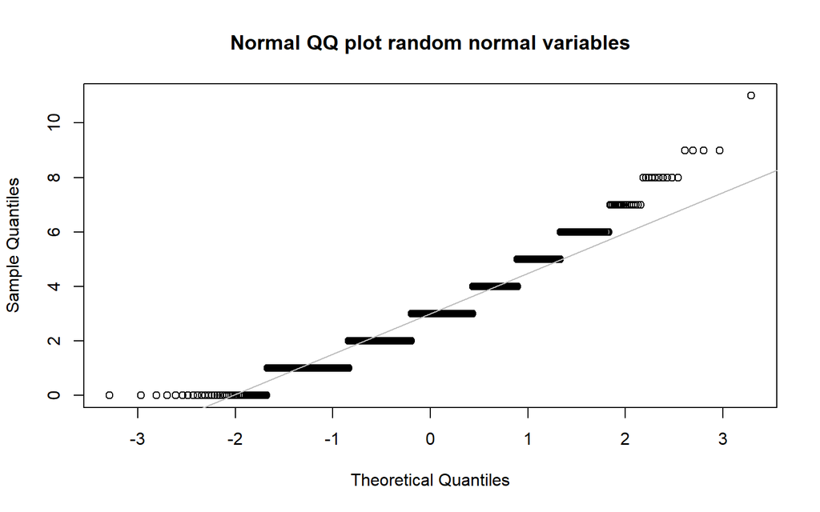

```r
qqnorm(zk, main = "Normal QQ plot random normal variables")
qqline(zk, col = "gray")
```

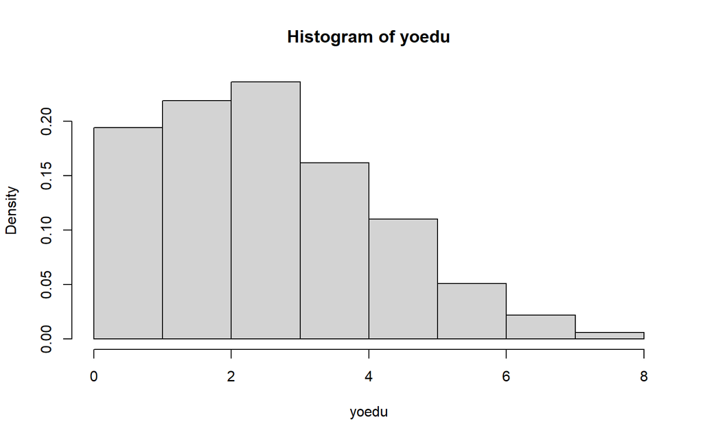

```r
hist(yoedu, probability = TRUE)
```

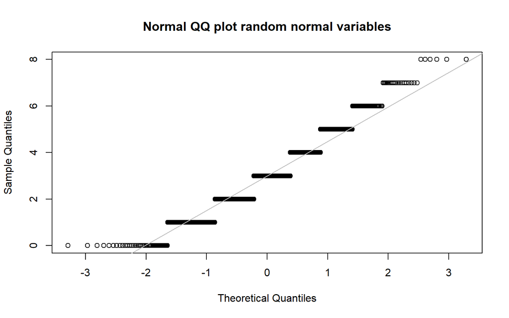

```r
qqnorm(yoedu, main = "Normal QQ plot random normal variables")
qqline(yoedu, col = "gray")
```

```r
# Both number of zombies killed and years of education are not normally distributed. I am not sure what common distribution they are drawn to.

#vbhavya Peer comment: I too had a really hard time figuring out what distribution the data were drawn from. To me, it seems Poisson (and I had to discuss with some of the other grad students to come to a conclusion). But it probably is poisson because if you look at the histogram, you see the distribution looks very similar to what a general Poisson looks like. I also googled a bit after I pushed the HW assignment and stumbled upon this https://stackoverflow.com/questions/31741742/how-to-identify-the-distribution-of-the-given-data-using-r where people share much better ways to figure out the distribution of a sample dataframe. I will give it a try for my final code and we can discuss it later if you'd like!
```

## Question 5: Now use the sample() function to sample ONE subset of 30 zombie survivors (without replacement) from this population and calculate the mean and sample standard deviation for each variable. Also estimate the standard error for each variable, and construct the 95% confidence interval for each mean. Note that for the variables that are not drawn from the normal distribution, you may need to base your estimate of the CIs on slightly different code than for the normal…

```r
#sample(d, 30, replace = FALSE)
#in this case the length of d is only 10 so this doesn't work

#height
hs <- sample(height, 30, replace = FALSE) #takes a random sample of 30 from the height dataset
mhs <- mean(hs) #takes mean of the 30 samples
sdhs <- sd(hs) # I'm honestly a little confused on the difference between sample standard deviation and standard error?
hsse <- sdhs/sqrt(30) #takes standard error of the 30 samples
lower <- mh - qnorm(1 - 0.05/2) * hsse
upper <- mh + qnorm(1 - 0.05/2) * hsse
ci <- c(lower, upper) #caclulates the confidence interval
ci
```

```
## [1] 66.29755 68.96265
```

```r
#weight
ws <- sample(weight, 30, replace = FALSE)
ws
```

```
##  [1] 144.1230 161.2081 115.0012 156.2562 161.8009 141.9159 174.2580 120.4763
##  [9] 132.8847 123.4594 168.0946 132.8371 137.0979 175.4212 144.0345 118.8991
## [17] 133.8565 147.7249 154.5637 148.6233 130.6773 125.8822 141.6098 133.6441
## [25] 124.7995 134.3688 108.6405 160.7283 181.6597 165.9423
```

```r
mws <- mean(ws)
sdws <- sd(ws)
sdws
```

```
## [1] 19.24438
```

```r
sews <- sdws/sqrt(30)
sews
```

```
## [1] 3.513526
```

```r
lower <- mw - qnorm(1 - 0.05/2) * sews  # (1-alpha)/2 each in the upper and lower tails of the distribution
upper <- mw + qnorm(1 - 0.05/2) * sews  # (1-alpha)/2 each in the upper and lower tails of the distribution
ci <- c(lower, upper)
ci
```

```
## [1] 137.0211 150.7939
```

```r
#age
as <- sample(age, 30, replace = FALSE)
as
```

```
##  [1] 19.81336 17.42398 26.52334 21.33672 19.44685 22.48088 20.00607 18.99540
##  [9] 16.32740 17.67434 19.98677 19.48839 22.05847 20.81643 18.06279 17.49842
## [17] 21.72252 20.23903 18.55274 21.30337 19.37227 21.30046 20.92256 20.69022
## [25] 21.40160 19.55997 18.79596 19.17136 10.66381 20.27556
```

```r
mas <- mean(as)
sdas <- sd(as)
sdas
```

```
## [1] 2.574
```

```r
seas <- sdas/sqrt(30)
seas
```

```
## [1] 0.4699459
```

```r
lower <- ma - qnorm(1 - 0.05/2) * seas  # (1-alpha)/2 each in the upper and lower tails of the distribution
upper <- ma + qnorm(1 - 0.05/2) * seas  # (1-alpha)/2 each in the upper and lower tails of the distribution
ci <- c(lower, upper)
ci
```

```
## [1] 19.12588 20.96804
```

```r
#for both zombies killed and years of education because they both were not normal distributions the central limit theorem will be used because these are samples and it can simulate a normal distribution - but honestly I don't know how to do that so any help would be appreciated! Or maybe is it supposed to be a t distribution?

#vbhavya Peer comment: So, I did this very round about way in which I approximated the Poisson distributions to a normal distribution (you can do that by calculating population mean, which will be the lambda. Then, for a normal approximation of a poisson, you can do rnorm(n = 30, mean = lambda, sd = sqrt(lambda))). I only thought of this way because I learnt in one of my stats courses that distributions can be approximated to another distribution but I honestly don't know if what I've done is right. I only converted the poisson to a normal so I could proceed with the usual code for CI.
#I think using a t-distribution to find the critical values might be a much better way. I don't see why it would be wrong.
#One of my friends googled 'how to calculate the CIs for a poisson distribution sample' and that worked for them too. But you'd need to know that the sample is drawn from a Poisson for that.

#zombies killed
zks <- sample(zk, 30, replace = FALSE)
zks
```

```
##  [1] 5 4 5 2 2 1 1 1 3 3 1 4 5 3 2 3 3 4 3 2 8 4 1 4 3 1 1 6 3 2
```

```r
mzks <- mean(zks)
sdzks <- sd(zks)
sdzks
```

```
## [1] 1.701926
```

```r
sezks <- sdzks/sqrt(30)
sezks
```

```
## [1] 0.3107277
```

```r
lower <- mzk - qnorm(1 - 0.05/2) * sezks  # (1-alpha)/2 each in the upper and lower tails of the distribution
upper <- mzk + qnorm(1 - 0.05/2) * sezks  # (1-alpha)/2 each in the upper and lower tails of the distribution
ci <- c(lower, upper)
ci
```

```
## [1] 2.382985 3.601015
```

```r
#years of education
edus <- sample(yoedu, 30, replace = FALSE)
edus
```

```
##  [1] 6 4 3 1 1 2 3 5 4 2 3 1 5 3 3 3 4 2 2 3 3 2 4 3 2 3 4 3 3 2
```

```r
medus <- mean(edus)
sdedu <- sd(edus)
sdedu
```

```
## [1] 1.188547
```

```r
seedu <- sdedu/sqrt(30)
seedu
```

```
## [1] 0.216998
```

```r
lower <- myoedu - qnorm(1 - 0.05/2) * seedu  # (1-alpha)/2 each in the upper and lower tails of the distribution
upper <- myoedu + qnorm(1 - 0.05/2) * seedu  # (1-alpha)/2 each in the upper and lower tails of the distribution
ci <- c(lower, upper)
ci
```

```
## [1] 2.570692 3.421308
```

## Question 6: Now draw 99 more random samples of 30 zombie apocalypse survivors, and calculate the mean for each variable for each of these samples. Together with the first sample you drew, you now have a set of 100 means for each variable (each based on 30 observations), which constitutes a sampling distribution for each variable. What are the means and standard deviations of this distribution of means for each variable?

```r
#height
hs2 <- NULL  # sets up a dummy variable
n <- 30 #number of samples
for (i in 1:99) {
    hs2[[i]] <- mean(sample(height, n, replace = FALSE))
} #draws 99 samples with 30 random numbers from height data set and takes the mean of each sample set
hs2 <- append(hs2, mhs, after = 99) #adds the mean from question 5 to the list
hs2 <- unlist(hs2) #unlist the variable
mean(hs2) # takes the mean
```

```
## [1] 67.59024
```

```r
sd(hs2) #takes the standard deviation
```

```
## [1] 0.689994
```

```r
#weight
ws2 <- NULL
for (i in 1:99) {
    ws2[[i]] <- mean(sample(weight, n, replace = FALSE))
}
ws2 <- append(ws2, mws, after = 99)
ws2 <- unlist(ws2)
mean(ws2)
```

```
## [1] 144.4655
```

```r
sd(ws2)
```

```
## [1] 3.077403
```

```r
#age
as2 <- NULL
for (i in 1:99) {
    as2[[i]] <- mean(sample(age, n, replace = FALSE))
}
as2 <- append(as2, mas, after = 99)
as2 <- unlist(as2)
mean(as2)
```

```
## [1] 20.07634
```

```r
sd(as2)
```

```
## [1] 0.4298875
```

```r
#zombies killed
zks2 <- NULL
for (i in 1:99) {
    zks2[[i]] <- mean(sample(zk, n, replace = FALSE))
}
zks2 <- append(zks2, mzks, after = 99) #adds the mean from the sample in question 5
zks2 <- unlist(zks2)
mean(zks2)
```

```
## [1] 2.997
```

```r
sd(zks2)
```

```
## [1] 0.3136296
```

```r
#years of education
yedus2 <- NULL
for (i in 1:99) {
    yedus2[[i]] <- mean(sample(yoedu, n, replace = FALSE))
}
yedus2 <- append(yedus2, medus, after = 99)
yedus2 <- unlist(yedus2)
mean(yedus2)
```

```
## [1] 2.989333
```

```r
sd(yedus2)
```

```
## [1] 0.3308622
```

## What do these sampling distributions look like (a graph might help here)? Are they normally distributed? What about for those variables that you concluded were not originally drawn from a normal distribution?

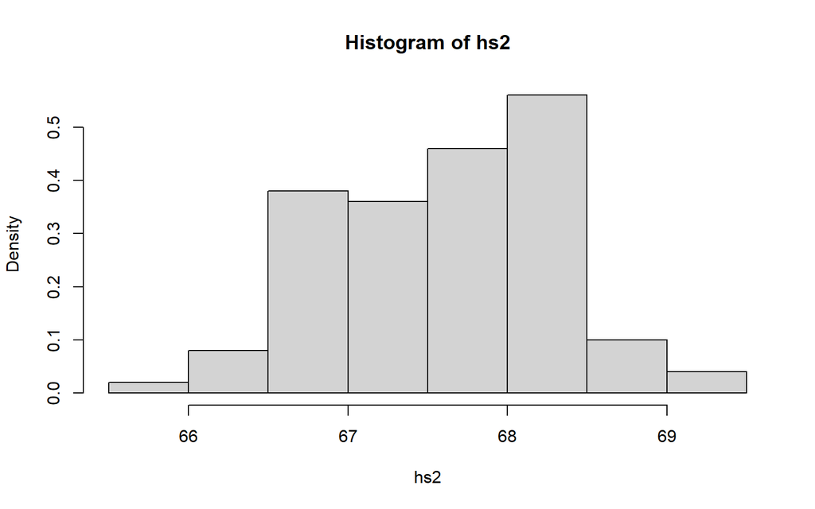

```r
#height
hist(hs2, probability = TRUE) #create histogram from sample distribution calculated in chunk above
```

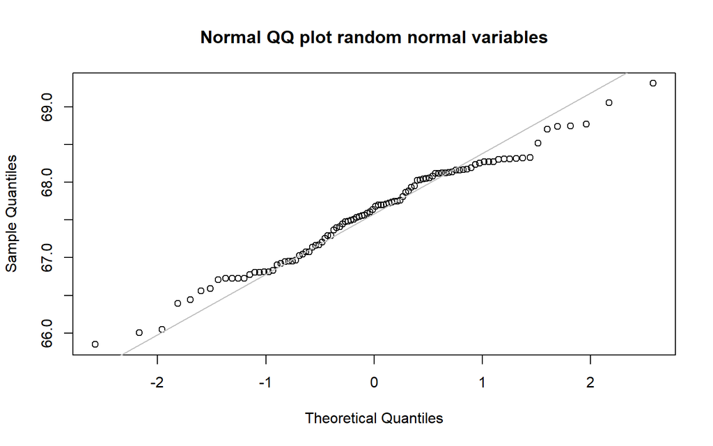

```r
qqnorm(hs2, main = "Normal QQ plot random normal variables")  #plots qqnorm graph based of hs2 data
qqline(hs2, col = "gray") #plot qqline
```

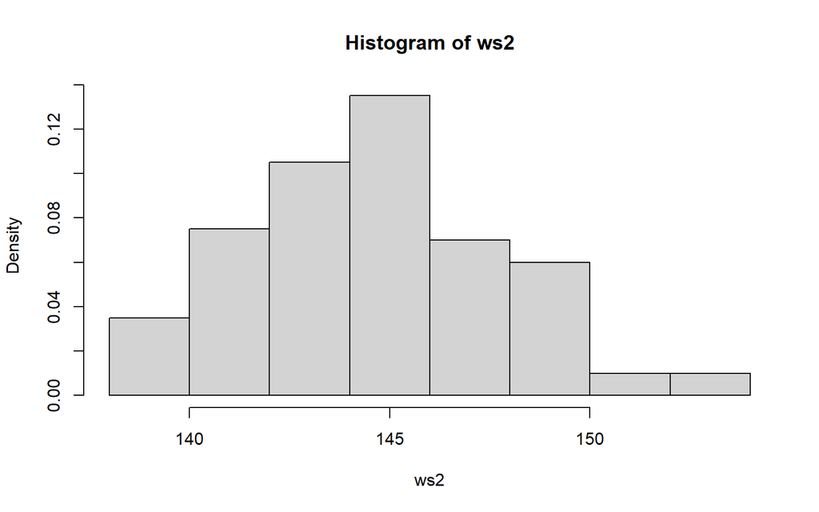

```r
#weight
hist(ws2, probability = TRUE)
```

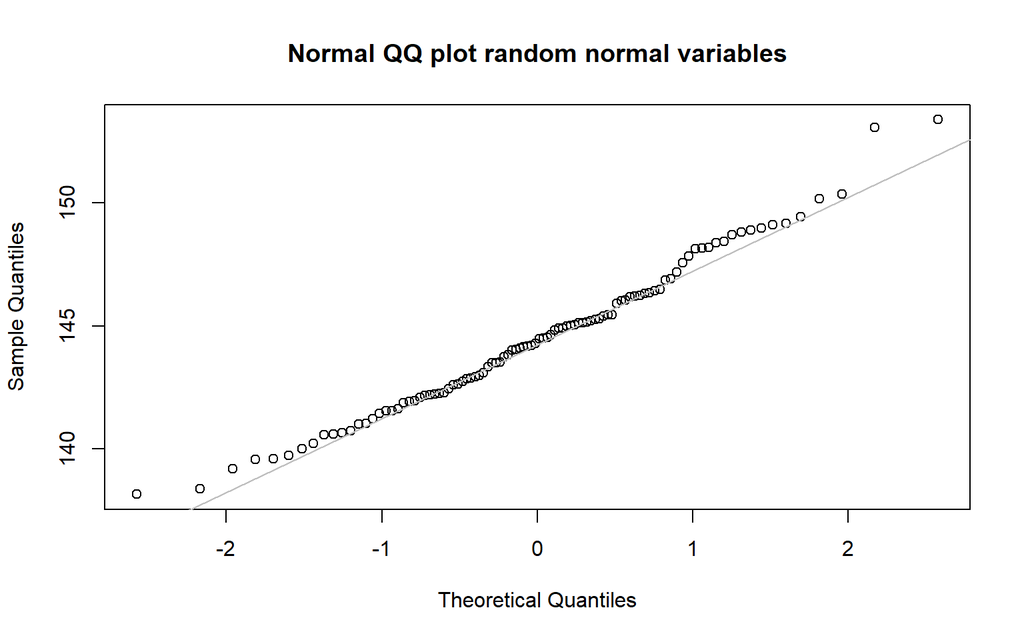

```r
qqnorm(ws2, main = "Normal QQ plot random normal variables")
qqline(ws2, col = "gray")
```

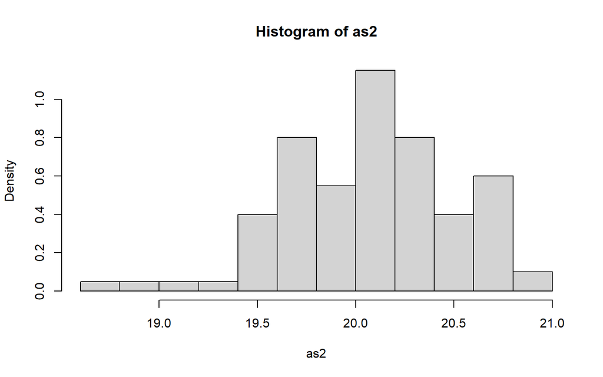

```r
#age
hist(as2, probability = TRUE)
```

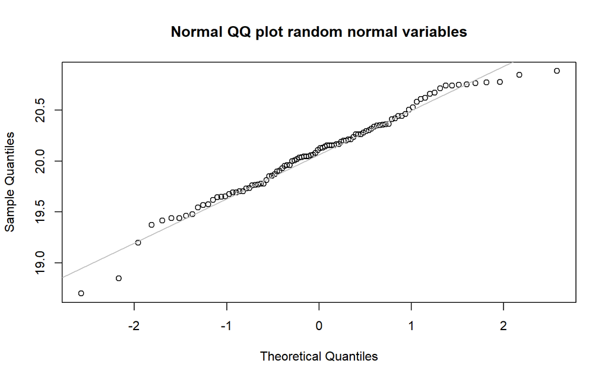

```r
qqnorm(as2, main = "Normal QQ plot random normal variables")
qqline(as2, col = "gray")
```

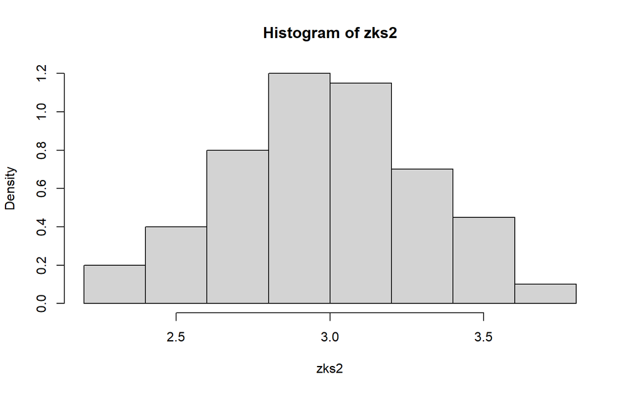

```r
#number of zombies killed
hist(zks2, probability = TRUE)
```

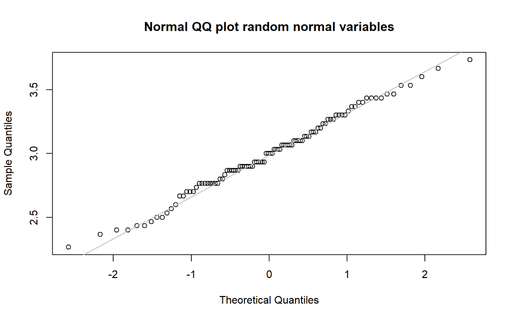

```r
qqnorm(zks2, main = "Normal QQ plot random normal variables")
qqline(zks2, col = "gray")
```

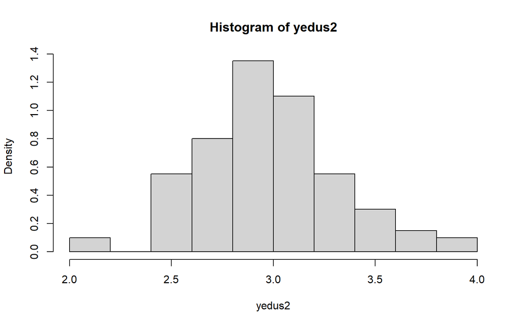

```r
#years of education
hist(yedus2, probability = TRUE)
```

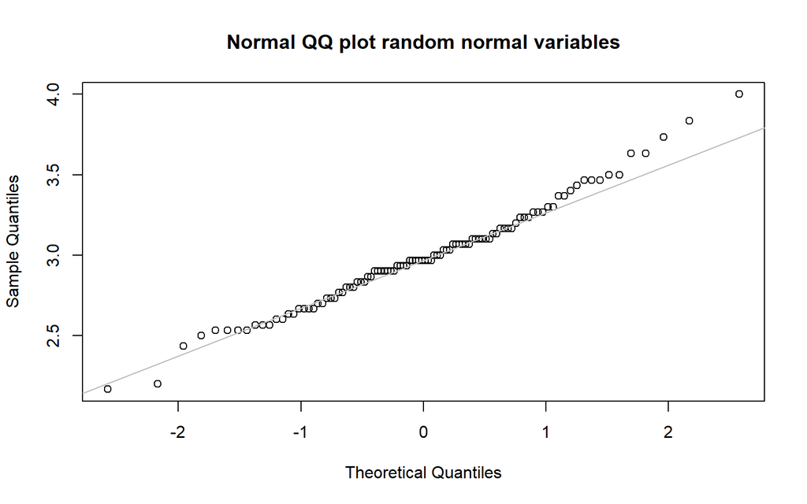

```r
qqnorm(yedus2, main = "Normal QQ plot random normal variables")
qqline(yedus2, col = "gray")
```

```r
# Most of the variables are normally distributed, of course this is a little variation like in the number of zombies killed. But compared to the original histograms of the population the qqline graph seem to follow the line more, especially in years of education and number of zombies killed, which were originally not.

#vbhavya Peer comment: I love that you checked using the qqnorm() function! Very thorough!
```

## Challenges Faced

1. Figuring out the formula to calculate standard deviation was hard for me to find and figure out how to use. But once I found it in the modules it was pretty straightforward.
2. Initially both of my ggplot scatter plots would not run and I could not figure out what was going wrong. After 30 minutes of reinstalling r studio and restarting my computer I figured out that I was just simply missing a ‘)’
3. Figuring out the difference between standard error and standard deviation is something I still don’t understand but I think my code is calculating the right numbers
4. I could not figure out how to take a sample from my data set d because its length was only 10 so I eventually came to the conclusion that I had to take samples from each of the variable columns I would be looking at.
5. I worked on trying to get 99 samples of size 30 for so long. But in the end and after staring at my code for many hours I took samples of each variable in a for loop